# LDAPlots

James Colee

## Introduction

The LDAPlots package was created to help with the interpretations of multivariate analysis resulting from the problem of having multiple response variables and a single categorical predictor variable. Some of the common ways of analyzing these types of problems is either through multivariate analysis of variance (MANOVA), analysis of similarities (ANOSIM), or permutational multivariate analysis of variance (PERMANOVA). The problem with all these methods is that there is not an easy way to visualize these results, when the categorical variable has more than three levels. Descriptions of these types of analysis and functions to perform them can be found in the package [vegan](https://cran.r-project.org/web/packages/vegan/vegan.pdf).

```r
library(LDAPlots)
```

## LDA Projection Plots

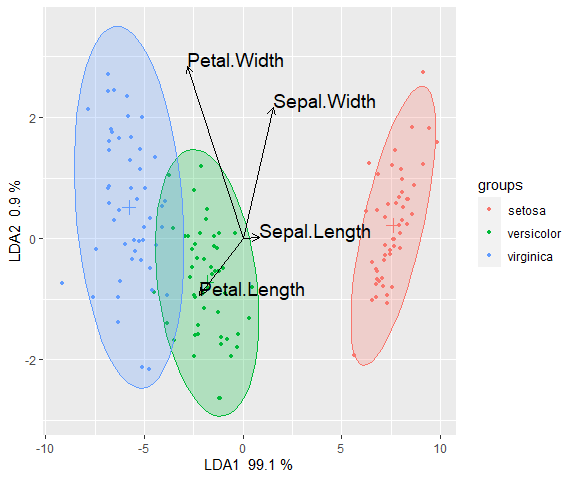

```r
library(MASS)
iris.lda <- lda(Species ~., data = iris)
p<-lda_gplot(lda=iris.lda, groups = iris$Species)
p
```

**Confidence Intervals**

Three types of confidence bounds can be produced by `lda_gplot`: asymptotic, bootstrap, and permutation. In all three cases the rotations are assumed to be constant. This means that only the rotated data needs to be bootstrapped or permuted depending on the desired confidence interval. Logically keep the rotations constant makes sense, otherwise each new LDA rotation would be projected into different 2 dimensional space.

**Asymptotic Confidence Circles**

The asymptotic confidence circles for the means can be added to the plot with `circles = TRUE` setting. The confidence circles have a radius of a square root of a chi square, with G degrees of freedom divided my the number of observations in each group.

$$asymptotic\,\,confidence\,\,circles\,\,radii = \sqrt\frac{\chi_{ G, 1-\alpha } }{n_{g}}$$

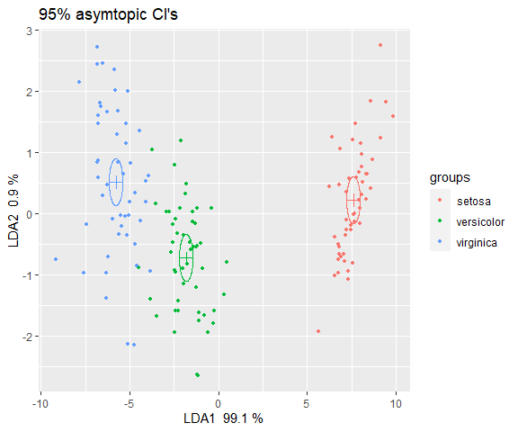

```r
library(ggplot2)
p<-lda_gplot(lda=iris.lda, groups = iris$Species,
             normal.CI = FALSE, circles = TRUE, biplot = FALSE)
p + ggtitle("95% asymtopic CI's")
```

**Bootstrap Confidence Intervals**

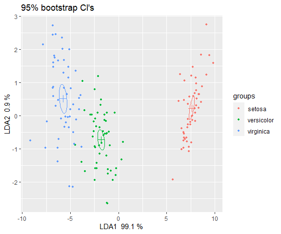

```r
p<-lda_gplot(lda=iris.lda, groups = iris$Species,
             normal.CI = FALSE,boot.CI = TRUE, fill = FALSE, biplot = FALSE)
p + ggtitle("95% bootstrap CI's")
```

**Permutation Confidence Intervals**

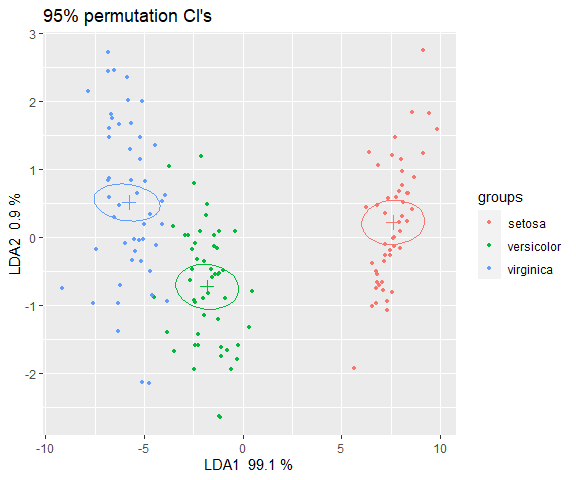

```r
p<-lda_gplot(lda=iris.lda, groups = iris$Species,
             normal.CI = FALSE,perm.CI = TRUE, fill = FALSE, biplot = FALSE)
p + ggtitle("95% permutation CI's")
```